# 标准数据类型

就像我们平时说的, 小数, 整数, 复数之间的区别一样, 在每种编程语言中, 数据都可以以不同的形式储存在内存中, 这些不同的形式就叫做**数据类型**.

用不同数据类型储存的数据, 具有不同的储存结构, 对应的也就有不同的使用方法和功能.

下面让我们来看一下python中的常用数据类型

**python中常用的数据类型有**

- 数字(Numbers)整数int, 浮点数float, 复数complex
- 布尔(Booleans)函数为bool, 含有的值为True和False
- 字符串(Strings)函数为str , Uniconde字符序列, 在引号内包含
- 列表(list)有序的值的序列
- 元组(tuple)有序的值的序列且不可改变
- 字典(Dictionaries)函数为dict, 无序的键值对的组合
- 集合(Sets)函数为set, 无序的不含重复值的序列

## 数字类型

**int 整数型 float浮点型 complex复数**

### 整数型int

**Python的整数长度没有限制，通常是连续分配的内存空间。**

```python
a = 256
type(a)
type(a)
```

```
int
```

### 浮点型float

浮点型就是我们常说的小数型

```python
a = 1.0
type(a)
```

```
float
```

也可以使用科学计数法进行表示

```python
a = 1.23e10
```

```python
b = 1.1e10
```

```python
c = 1.45e-5
```

```python
a + b
```

```
23300000000.0
```

```python
a + c
```

```
12300000000.000015
```

## 数字类型的转换

```python
int(8.7)
```

```
8
```

```python
float(8)
```

```
8.0
```

```python
float(8.88888)
```

```
8.88888
```

```python
int("1")
```

```
1
```

## 数字的计算

下面以a=10 ,b=20为例进行计算

| 运算符 | 描述 | 实例 |
| --- | --- | --- |
| + | 加 | 两个对象相加 a + b 输出结果 30 |
| - | 减 | 得到负数或是一个数减去另一个数 a - b 输出结果 -10 |
| * | 乘 | 两个数相乘或是返回一个被重复若干次的字符串 a * b 输出结果 200 |
| / | 除 | x除以y b / a 输出结果 2 |
| // | 取整除 | 返回商的整数部分 9//2 输出结果 4 , 9.0//2.0 输出结果 4.0 |
| % | 取余 | 返回除法的余数 b % a 输出结果 0 |
| ** | 幂 | 返回x的y次幂 a**b 为10的20次方， 输出结果 100000000000000000000 |

```python
# Python 内置的基础运算符
# + - * / ** // %
```

```python
3 ** 3
```

```
27
```

```python
9 / 6
```

```
1.5
```

```python
9 // 6
```

```
1
```

```python
9 % 6
```

```
3
```

### 练习题:

一个苹果的价格是10元, 一个梨的价格是12元, 如果买6个苹果, 三个梨, 需缴纳交易税为22%, 总共需要花费多少钱?

### math科学计算库

|  | python内置的一些计算函数： |
| --- | --- |
| abs(x) | 返回x的绝对值，类型随x |
| max(n1, n2, ...) | 返回最大值 |
| min(n1, n2, ...) | 返回最小值 |
| round(x [,n]) | 默认返回浮点数x的四舍五入值，如给出n值，则代表舍入到小数点后的n位。例如round(1.23456, 3)返回1.235 |

|  | python还提供科学计算等库，例如math，导入math库后，常用的函数有： |
| --- | --- |
| fabs(x) | 返回x的绝对值，类型是浮点数 |
| ceil(x) | 取x的上入整数，如math.ceil(4.1)返回5 |
| floor(x) | 取x的下入整数，如math.floor(4.9)返回4 |
| exp(x) | 返回e的x次幂，e是自然常数 |
| sqrt(x) | 返回x的平方根，返回值是float类型 |
| modf(x) | 返回x的整数部分和小数部分，两部分的符号与x相同，整数部分以浮点型表示。例如math.modf(4.333)，返回元组(0.3330000000000002, 4.0) |
| log10(x) | 返回以10为基数的x的对数，返回值类型是浮点数 |
| log(x,y) | 返回以y为基数的x的对数，返回值类型是浮点数 |
| pow(x, y) | 返回x的y次幂，即x**y |

```python
import math
```

```python
math.exp(3)
```

```
20.085536923187668
```

```python
pi
```

```
3.141592653589793
```

```python
math.degrees(pi)
```

```
180.0
```

### 小练习: 计算根号5加上17的平方的结果取10的对数的

$$ \log_{10}{(\sqrt{5} + 17^2)} $$

### 复合赋值运算符

| 运算符 | 描述 | 实例 |
| --- | --- | --- |
| += | 加法赋值运算符 | c += a 等效于 c = c + a |
| -= | 减法赋值运算符 | c -= a 等效于 c = c - a |
| *= | 乘法赋值运算符 | c *= a 等效于 c = c* a |
| /= | 除法赋值运算符 | c /= a 等效于 c = c / a |
| %= | 取模赋值运算符 | c %= a 等效于 c = c % a |
| **= | 幂赋值运算符 | c **= a 等效于 c = c** a |
| //= | 取整除赋值运算符 | c //= a 等效于 c = c // a |

**小练习：用普通运算符和复合运算符分别计算以下问题：**

有一个数字，数字的值为12，让这个数字在原有的基础上减去2，求减去后的结果是多少。

### python中的比较运算符

| 运算符 | 描述 | 示例 |
| --- | --- | --- |
| == | 检查两个操作数的值是否相等，如果是则条件变为真。 | 如a=3,b=3则（a == b) 为 true. |
| != | 检查两个操作数的值是否相等，如果值不相等，则条件变为真。 | 如a=1,b=3则(a != b) 为 true. |
| > | 检查左操作数的值是否大于右操作数的值，如果是，则条件成立。 | 如a=7,b=3则(a > b) 为 true. |
| < | 检查左操作数的值是否小于右操作数的值，如果是，则条件成立。 | 如a=7,b=3则(a < b) 为 false. |
| >= | 检查左操作数的值是否大于或等于右操作数的值，如果是，则条件成立。 | 如a=3,b=3则(a >= b) 为 true. |
| <= | 检查左操作数的值是否小于或等于右操作数的值，如果是，则条件成立。 | 如a=3,b=3则(a <= b) 为 true. |

```python
a = 3
b = 4
a == b
```

```
False
```

```python
a < b
```

```
True
```

```python
a >= b
```

```
False
```

### 逻辑运算符

| 运算符 | 逻辑表达式 | 描述 | 实例 |
| --- | --- | --- | --- |
| and | x and y | 布尔"与" - 如果 x 为 False，x and y 返回 False，否则它返回 y 的计算值。 | (a and b) 返回 20。 |
| or | x or y | 布尔"或" - 如果 x 是 True，它返回 True，否则它返回 y 的计算值。 | (a or b) 返回 10。 |
| not | not x | 布尔"非" - 如果 x 为 True，返回 False 。如果 x 为 False，它返回 True。 | not(a and b) 返回 False |

```python
a = 3
b = 4
c = 5
```

## 字符串

字符串是指以""双引号, 或者''单引号括起来的任意文本, 例如"abaa", '1232'凡是在引号中的都是字符串

```python
s = "你好"
```

```python
s1 = "abcd"
```

```python
s2 = "3456341"
```

### 长字符串

当字符串比较长，一行写不下，需要换行的时候，可以使用长字符串

```python
s_length = """知而不行，谓之不诚。
行而不成，谓之不能。
知而行，是赤诚之心，行而能，是贯彻到底，已经很难被其他人和事影响了。
而知行合一的前提是，格物致知，将一件事研究到极致，变成自己的知识。
比如做菜，将做菜这门手艺做到尽善尽美，色香味无可挑剔；比如建筑，将楼宇亭台建得坚固美观使用，美轮美奂，风雨不倒地震不塌；比如造船，将造船原理吃透，用料坚固，风浪不沉。
这便是格物致知，将一件东西一件事情研究到极点，明白其中所有的道理。
做到格物致知，方能知行合一。
"""
```

```python
print(s_length)
```

```
知而不行，谓之不诚。
行而不成，谓之不能。
知而行，是赤诚之心，行而能，是贯彻到底，已经很难被其他人和事影响了。
而知行合一的前提是，格物致知，将一件事研究到极致，变成自己的知识。
比如做菜，将做菜这门手艺做到尽善尽美，色香味无可挑剔；比如建筑，将楼宇亭台建得坚固美观使用，美轮美奂，风雨不倒地震不塌；比如造船，将造船原理吃透，用料坚固，风浪不沉。
这便是格物致知，将一件东西一件事情研究到极点，明白其中所有的道理。
做到格物致知，方能知行合一。
```

```python
s_length
```

```
'知而不行，谓之不诚。 \n行而不成，谓之不能。 \n知而行，是赤诚之心，行而能，是贯彻到底，已经很难被其他人和事影响了。 \n而知行合一的前提是，格物致知，将一件事研究到极致，变成自己的知识。 \n比如做菜，将做菜这门手艺做到尽善尽美，色香味无可挑剔；比如建筑，将楼宇亭台建得坚固美观使用，美轮美奂，风雨不倒地震不塌；比如造船，将造船原理吃透，用料坚固，风浪不沉。 \n这便是格物致知，将一件东西一件事情研究到极点，明白其中所有的道理。 \n做到格物致知，方能知行合一。\n'
```

### 关于单引号和双引号以及引号冲突问题

```python
# 单引号和双引号没有区别
s3 = "abc"
s3
```

```
'abc'
```

```python
s4 = 'bcd'
s4
```

```
'bcd'
```

当字符串本身内容中包含有引号时，可能会引起引号冲突

```python
s5 = "Rose:"You jump,I jump!""
```

[output not shown]

```python
# 但是如果引号不相同则不会
s6 = '王小波："你好哇，李银河！".'
```

```python
s7 = "王小波：“你好哇，李银河！”."
```

```python
s8 = "王小波：'你好哇，李银河！'."
```

对于这种冲突，可以使用转义符号\，对该符号进行转义

```python
s9 = "Rose:\"You jump,I jump!\""
s9
```

```
'Rose:"You jump,I jump!"'
```

### 字符串的数据类型和函数

```python
type("a")
```

```
str
```

```python
str(1234)
```

```
'1234'
```

```python
str(3.14)
```

```
'3.14'
```

```python
str(True)
```

```
'True'
```

```python
len(str1)
```

```
9
```

注: 字符串也是一个可迭代对象, 迭代次数就是字符串的字符数

### 字符串的拼接和重复

字符串 使用 + 相当于拼接两个字符串

字符串 * n , 相当于把字符串重复n次

```python
"梅西" + "C罗"
```

```
'梅西C罗'
```

```python
"梅西"*100
```

```
'梅西梅西梅西梅西梅西梅西梅西梅西梅西梅西梅西梅西梅西梅西梅西梅西梅西梅西梅西梅西梅西梅西梅西梅西梅西梅西梅西梅西梅西梅西梅西梅西梅西梅西梅西梅西梅西梅西梅西梅西梅西梅西梅西梅西梅西梅西梅西梅西梅西梅西梅西梅西梅西梅西梅西梅西梅西梅西梅西梅西梅西梅西梅西梅西梅西梅西梅西梅西梅西梅西梅西梅西梅西梅西梅西梅西梅西梅西梅西梅西梅西梅西梅西梅西梅西梅西梅西梅西梅西梅西梅西梅西梅西梅西梅西梅西梅西梅西梅西梅西'
```

```python
"ABC" + "abc"
```

```
'ABCabc'
```

```python
"ABC" * 10
```

```
'ABCABCABCABCABCABCABCABCABCABC'
```

```python
print("-"*50)
```

[output not shown]

### 字符串的索引和切片

字符串也是一个可迭代对象, 也就是说每一个字符串实际上都有一个对应的索引值。

索引值从零开始计算，每一个字符对应一个唯一的索引值。

索引值也可以从后往前算，后面从负一开始计算。

```python
test = "零一二三四五六七八九"
```

```python
test[0]
```

```
'零'
```

```python
test[1]
```

```
'一'
```

**有的时候我不仅仅想取出字符串的其中一个字符,想要取出其中一部分,这时候应该怎么做呢?**

**字符串切片的标准语法:**

string[开始位置:终止位置:步长和方向]

注意：选取的区间属于左闭右开型，即从"起始"位开始，到"结束"位的前一位结束（不包含结束位本身)。

这里以字符串为例进行讲解,实际上列表也会具有相同的方法.

```python
test = "零一二三四五六七八九"
```

```python
test[3:5]
```

```
'三四'
```

```python
test[1:4]
```

```
'一二三'
```

```python
test[0:5]
```

```
'零一二三四'
```

```python
test[:5]
```

```
'零一二三四'
```

```python
test[2:6:2]
```

```
'二四'
```

### 小练习：有一个字符串，按照要求切除内容

practice = "有些人总是这么不一样，看了一眼，就能让人记住很多年。而有些人，哪怕看了再多年，也没在心头住下。"

在字符串中切片出以下字符

1. 有些人
2. 这么不一样
3. 心头住下
4. 下住头心
5. 哪看再年
6. 下心也

### 小练习： 给定一个字符串aStr, 请反转字符串

```python
aStr = "abcdefg"
```

### 转义字符

转义字符有很多,这里介绍几个常见的

1. \n 表示换行
2. \t 表示制表符
3. \ 转义反斜杠
4. \" 把引号转义成普通字符串

转义字符如可以把本身没有含义的普通字符转换成特殊功能字符，也可以把本身有特殊功能的字符转换成普通字符。

```python
"\"ABC\""
```

```
'"ABC"'
```

[output not shown]

```python
'\'ABC\nbb'
```

```
"'ABC\nbb"
```

```python
print('\'ABC\nbb')
```

```
'ABC
bb
```

注： python中也可以用r''这种语法创建原生字符串,原生字符串中的字符串不进行转义

```python
r'\'ABC\nbb'
```

```
"\\'ABC\\nbb"
```

```python
print(r'\'ABC\nbb')
```

```
\'ABC\nbb
```

### 字符串方法

字符串的方法很多，这里只讲一些比较常用的字符串处理方法

#### <1>find

检测 str 是否包含在 mystr中，如果是返回开始的索引值，否则返回-1

mystr.find(str, start=0, end=len(mystr))

```python
s_find = "abcdefgabc"
```

```python
s_find.find('a')
```

```
0
```

```python
s_find.find('f')
```

```
5
```

#### 小练习： 查找出“上”字的索引值，并利用切片提取出上及后面的两个字

```python
s_test = """仗剑红尘已是癫，有酒平步上青天。
游星戏斗弄日月，醉卧云端笑人间。"""
```

#### <3>count

返回 str在start和end之间 在 mystr里面出现的次数

mystr.count(str, start=0, end=len(mystr))

```python
s_test = """御剑乘风来，除魔天地间，
有酒乐逍遥，无酒我亦颠，
一饮尽江河，再饮吞日月，
千杯醉不倒，唯我酒剑仙。"""
```

```python
s_test.count('剑')
```

```
2
```

```python
s_test.count('日')
```

```
1
```

#### <4>replace

把 mystr 中的 str1 替换成 str2,如果 count 指定，则替换不超过 count 次.

mystr.replace(str1, str2, mystr.count(str1))

```python
s10 = """桃花坞里桃花庵，桃花庵里桃花仙；桃花仙人种桃树，又摘桃花换酒钱。
酒醒只在花前坐，酒醉还来花下眠；半醒半醉日复日，花落花开年复年。
但愿老死花酒间，不愿鞠躬车马前；车尘马足贵者趣，酒盏花枝贫者缘。
若将富贵比贫贱，一在平地一在天；若将贫贱比车马，他得驱驰我得闲。
世人笑我太疯癫，我笑世人看不穿；不见五陵豪杰墓，无花无酒锄作田。"""
```

```python
s10.replace('桃花',"菊花")
```

```
'菊花坞里菊花庵，菊花庵里菊花仙；菊花仙人种桃树，又摘菊花换酒钱。\n酒醒只在花前坐，酒醉还来花下眠；半醒半醉日复日，花落花开年复年。\n但愿老死花酒间，不愿鞠躬车马前；车尘马足贵者趣，酒盏花枝贫者缘。\n若将富贵比贫贱，一在平地一在天；若将贫贱比车马，他得驱驰我得闲。\n世人笑我太疯癫，我笑世人看不穿；不见五陵豪杰墓，无花无酒锄作田。'
```

```python
print(s10.replace('桃花',"菊花"))
```

```
菊花坞里菊花庵，菊花庵里菊花仙；菊花仙人种桃树，又摘菊花换酒钱。
酒醒只在花前坐，酒醉还来花下眠；半醒半醉日复日，花落花开年复年。
但愿老死花酒间，不愿鞠躬车马前；车尘马足贵者趣，酒盏花枝贫者缘。
若将富贵比贫贱，一在平地一在天；若将贫贱比车马，他得驱驰我得闲。
世人笑我太疯癫，我笑世人看不穿；不见五陵豪杰墓，无花无酒锄作田。
```

这时候我们要注意看一下s10到底变没变,为什么?

#### 小练习：

统计出桃花诗中桃花一共出现多少次

然后把桃花诗中的标点符号都换成英文标点符号

#### <5>split

以 str 为分隔符切片 mystr，如果 maxsplit有指定值，则仅分隔 maxsplit 个子字符串

mystr.split(str=" ", 2)

```python
s11 = 'Forget the memories, continue to be life, miss, just pass by.'
```

```python
s11.split(' ')
```

```
['Forget',
 'the',
 'memories,',
 'continue',
 'to',
 'be',
 'life,',
 'miss,',
 'just',
 'pass',
 'by.']
```

```python
s11.split(',')
```

```
['Forget the memories', ' continue to be life', ' miss', ' just pass by.']
```

```python
s10 = """桃花坞里桃花庵，桃花庵里桃花仙；桃花仙人种桃树，又摘桃花换酒钱。
酒醒只在花前坐，酒醉还来花下眠；半醒半醉日复日，花落花开年复年。
但愿老死花酒间，不愿鞠躬车马前；车尘马足贵者趣，酒盏花枝贫者缘。
若将富贵比贫贱，一在平地一在天；若将贫贱比车马，他得驱驰我得闲。
世人笑我太疯癫，我笑世人看不穿；不见五陵豪杰墓，无花无酒锄作田。"""
```

```python
s10.split('，')
```

```
['桃花坞里桃花庵',
 '桃花庵里桃花仙；桃花仙人种桃树',
 '又摘桃花换酒钱。\n酒醒只在花前坐',
 '酒醉还来花下眠；半醒半醉日复日',
 '花落花开年复年。\n但愿老死花酒间',
 '不愿鞠躬车马前；车尘马足贵者趣',
 '酒盏花枝贫者缘。\n若将富贵比贫贱',
 '一在平地一在天；若将贫贱比车马',
 '他得驱驰我得闲。\n世人笑我太疯癫',
 '我笑世人看不穿；不见五陵豪杰墓',
 '无花无酒锄作田。']
```

```python
s10.split('桃花')
```

```
['',
 '坞里',
 '庵，',
 '庵里',
 '仙；',
 '仙人种桃树，又摘',
 '换酒钱。\n酒醒只在花前坐，酒醉还来花下眠；半醒半醉日复日，花落花开年复年。\n但愿老死花酒间，不愿鞠躬车马前；车尘马足贵者趣，酒盏花枝贫者缘。\n若将富贵比贫贱，一在平地一在天；若将贫贱比车马，他得驱驰我得闲。\n世人笑我太疯癫，我笑世人看不穿；不见五陵豪杰墓，无花无酒锄作田。']
```

```python
s10.split('\n')
```

```
['桃花坞里桃花庵，桃花庵里桃花仙；桃花仙人种桃树，又摘桃花换酒钱。',
 '酒醒只在花前坐，酒醉还来花下眠；半醒半醉日复日，花落花开年复年。',
 '但愿老死花酒间，不愿鞠躬车马前；车尘马足贵者趣，酒盏花枝贫者缘。',
 '若将富贵比贫贱，一在平地一在天；若将贫贱比车马，他得驱驰我得闲。',
 '世人笑我太疯癫，我笑世人看不穿；不见五陵豪杰墓，无花无酒锄作田。']
```

#### splitlines

按照行分隔，返回一个包含各行作为元素的列表

mystr.splitlines()

```python
split_test = """When you are old and grey and full of sleep,
And nodding by the fire，take down this book,
And slowly read,and dream of the soft look
Your eyes had once,and of their shadows deep;
How many loved your moments of glad grace,
And loved your beauty with love false or true,
But one man loved the pilgrim Soul in you
And loved the sorrows of your changing face;
And bending down beside the glowing bars,
Murmur,a little sadly,how Love fled
And paced upon the mountains overhead
And hid his face amid a crowd of stars."""
```

```python
split_test.splitlines()
```

```
['When you are old and grey and full of sleep,',
 'And nodding by the fire，take down this book,',
 'And slowly read,and dream of the soft look ',
 'Your eyes had once,and of their shadows deep; ',
 'How many loved your moments of glad grace, ',
 'And loved your beauty with love false or true,',
 'But one man loved the pilgrim Soul in you',
 'And loved the sorrows of your changing face;',
 'And bending down beside the glowing bars,',
 'Murmur,a little sadly,how Love fled',
 'And paced upon the mountains overhead',
 'And hid his face amid a crowd of stars.']
```

```python
split_test.splitlines(True)
```

```
['When you are old and grey and full of sleep,\n',
 'And nodding by the fire，take down this book,\n',
 'And slowly read,and dream of the soft look \n',
 'Your eyes had once,and of their shadows deep; \n',
 'How many loved your moments of glad grace, \n',
 'And loved your beauty with love false or true,\n',
 'But one man loved the pilgrim Soul in you\n',
 'And loved the sorrows of your changing face;\n',
 'And bending down beside the glowing bars,\n',
 'Murmur,a little sadly,how Love fled\n',
 'And paced upon the mountains overhead\n',
 'And hid his face amid a crowd of stars.']
```

#### 小练习: 分割字符串

1. 使用空格进行分割,使用逗号进行字符串分割.
2. 使用换行符分割

```python
prictice = """Never mind, I'll find someone like you
I wish nothing but the best for you, too
Don't forget me, I beg, I remember you said
Sometimes it lasts in love, but sometimes it hurts instead
Sometimes it lasts in love, but sometimes it hurts instead
You know how the time flies
Only yesterday was the time of our lives"""
```

### 字符串的格式化

```python
a = "美丽的"
b = "你在哪里"
```

```python
"你好吗, {}张小姐{}".format(a,b)
```

```
'你好吗, 美丽的张小姐你在哪里'
```

```python
"你好吗, {1}张小姐{0}".format(b,a )
```

```
'你好吗, 美丽的张小姐你在哪里'
```

```python
"你好吗, {形容词}张小姐{问她在哪}".format(形容词=a,问她在哪=b )
```

```
'你好吗, 美丽的张小姐你在哪里'
```

```python
"{0}就是一个大城市{1}".format("开封","的表率")
```

```
'开封就是一个大城市的表率'
```

```python
"{0}就是一个大城市{1}, {0}房价很贵, {0}是一个古城".format("郑州","的代表")
```

```
'郑州就是一个大城市的代表, 郑州房价很贵, 郑州是一个古城'
```

```python
"{城市}就是一个大城市{描述}, {城市}房价很贵, {城市}是一个古城".format(城市="郑州",描述="的代表")
```

```
'郑州就是一个大城市的代表, 郑州房价很贵, 郑州是一个古城'
```

#### 小练习

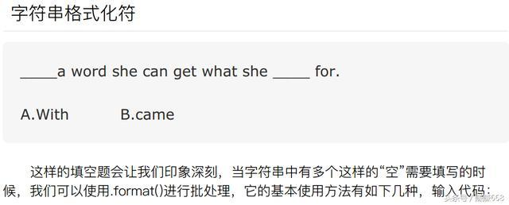

## 字符串其他方法--相对不常用(自学)

#### lower

转换 mystr 中所有大写字符为小写 mystr.lower()

#### upper

转换 mystr 中的小写字母为大写 mystr.upper()

```python
a = "ADFEdifeiASF"
```

```python
a.lower()
```

```
'adfedifeiasf'
```

```python
'sdfsdfefsf'.upper()
```

```
'SDFSDFEFSF'
```

#### strip

删除mystr字符串两端的空白字符

```python
s12 = " 也许这就是一段注定的缘分吧  "
```

```python
b = input("输入您的用户名: ")
```

```
输入您的用户名: y12345567
```

```python
b
```

```
'y12345567 '
```

```python
b.strip()
```

```
'y12345567'
```

```python
b = " goo gle    "
b.strip()
```

```
'goo gle'
```

也可以用于去掉字符串两端的其他字符

#### join

mystr 中每个字符后面插入str,构造出一个新的字符串

mystr.join(str)

```python
"-->".join("河南大学在开封")
```

```
'河-->南-->大-->学-->在-->开-->封'
```

```python
"===".join("|--快使用双截棍--|")
```

```
'|===-===-===快===使===用===双===截===棍===-===-===|'
```

#### 判断字符串内的元素类型

isalpha: 如果 mystr 所有字符都是字母 则返回 True,否则返回 False

mystr.isalpha()

isdigit: 如果 mystr 只包含数字则返回 True 否则返回 False.

mystr.isdigit()

isalnum: 如果 mystr 所有字符都是字母或数字则返回 True,否则返回 False

mystr.isalnum()

isspace: 如果 mystr 中只包含空格，则返回 True，否则返回 False.

mystr.isspace()

```python
a = '13134234'
```

```python
a.isdigit()
```

```
True
```

```python
a = 'sdfefwefe'
b = '234234'
```

```python
a.isalpha()
```

```
True
```

```python
a.isdigit()
```

```
False
```

```python
b.isdigit()
```

```
True
```

[output not shown]

[output not shown]

## 作业

```python
# x = "234567ASDsdfghj"  #切片和索引 ,  切片出AS两个字母
x = "234567ASDsdfghj"
```

```python
# x = "hello"     #显示字符串长度，注意是从1开始
x = "hello"
```

```python
x = "hello world ASDF"  #小写变为大写
```

```python
x = "234567ASDsdfghj"  #大写变为小写
```

```python
x = "     hello world     "     #删除两边空格
```

```python
x = "234567ASDsd\nfASDghjASD\n"  #以\n行分隔，返回一个包含元素的列表
```

```python
x = "234567ASDsdfASDghjASD"  #以A分隔x，并可指定次数
```

```python
x = "234567ASDsdfASDghjASD"  #替换字符串，并且可指定次数   'ASD'替换为'ABC'
```